# Palmer Archipelago Penguin Dataset

The Palmer Archipelago Penguin Dataset contains biological and ecological data collected from three penguin species inhabiting the Palmer Archipelago, Antarctica. The primary goal is to classify these penguins into their respective species based on the provided features.

### Objective:

- Conduct Exploratory Data Analysis (EDA) to uncover patterns and insights within the dataset.
- Evaluate the performance of the Linear Discriminant Analysis (LDA) model using key metrics such as:

  ```
    Precision
    Recall
    F1 Score
    Accuracy
    Confusion Matrix
  ```

- Compare the results with those of a Random Forest (RF) model to assess which approach provides better classification performance.

```python
## Import libraries

import pandas as pd
import seaborn as sns
import numpy as np
import matplotlib.pyplot as plt
from statsmodels.stats.outliers_influence import variance_inflation_factor
```

```python
## load the dataset

df = pd.read_csv("penguins_size.csv")
```

```python
# print the concise summery of the dataset
df.info()
```

```
<class 'pandas.core.frame.DataFrame'>
RangeIndex: 344 entries, 0 to 343
Data columns (total 7 columns):
 #   Column             Non-Null Count  Dtype
---  ------             --------------  -----
 0   species            344 non-null    object
 1   island             344 non-null    object
 2   culmen_length_mm   342 non-null    float64
 3   culmen_depth_mm    342 non-null    float64
 4   flipper_length_mm  342 non-null    float64
 5   body_mass_g        342 non-null    float64
 6   sex                334 non-null    object
dtypes: float64(4), object(3)
memory usage: 18.9+ KB
```

```python
print("Tota Rows and Columns (Rows,Columns) : ",df.shape)
#print first five rows of the dataset
df.head(5)
```

```
Tota Rows and Columns (Rows,Columns) :  (344, 7)
```

|  | species | island | culmen_length_mm | culmen_depth_mm | flipper_length_mm | body_mass_g | sex |
| --- | --- | --- | --- | --- | --- | --- | --- |
| 0 | Adelie | Torgersen | 39.1 | 18.7 | 181.0 | 3750.0 | MALE |
| 1 | Adelie | Torgersen | 39.5 | 17.4 | 186.0 | 3800.0 | FEMALE |
| 2 | Adelie | Torgersen | 40.3 | 18.0 | 195.0 | 3250.0 | FEMALE |
| 3 | Adelie | Torgersen | NaN | NaN | NaN | NaN | NaN |
| 4 | Adelie | Torgersen | 36.7 | 19.3 | 193.0 | 3450.0 | FEMALE |

```python
#print concise summery of the dataset
df.describe()
```

|  | culmen_length_mm | culmen_depth_mm | flipper_length_mm | body_mass_g |
| --- | --- | --- | --- | --- |
| count | 342.000000 | 342.000000 | 342.000000 | 342.000000 |
| mean | 43.921930 | 17.151170 | 200.915205 | 4201.754386 |
| std | 5.459584 | 1.974793 | 14.061714 | 801.954536 |
| min | 32.100000 | 13.100000 | 172.000000 | 2700.000000 |
| 25% | 39.225000 | 15.600000 | 190.000000 | 3550.000000 |
| 50% | 44.450000 | 17.300000 | 197.000000 | 4050.000000 |
| 75% | 48.500000 | 18.700000 | 213.000000 | 4750.000000 |
| max | 59.600000 | 21.500000 | 231.000000 | 6300.000000 |

# Exploratory data analysis (EDA)

```python
#count total rows in each column which contain null values
df.isna().sum()
```

```
species               0
island                0
culmen_length_mm      2
culmen_depth_mm       2
flipper_length_mm     2
body_mass_g           2
sex                  10
dtype: int64
```

```python
#'duplicated()' function in pandas return the duplicate row as True and othter as False
#for counting the duplicate elements we sum all the rows
sum(df.duplicated())
```

```
0
```

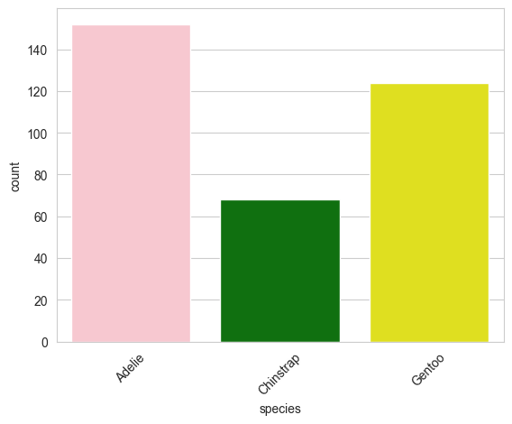

```python
#see how many species
sns.set_style("whitegrid")

custom_palette = {'Adelie': 'pink', 'Chinstrap': 'green', 'Gentoo': 'yellow'}

# Countplot with color based on species
sns.countplot(x='species', data=df, palette=custom_palette)

plt.xticks(rotation=45)

plt.show()
```

the imbalance in the dataset where Chinstrap penguins account for only 19.8% and Adelie penguins the majority at 44.2%,

Unbalanced distribution between species.

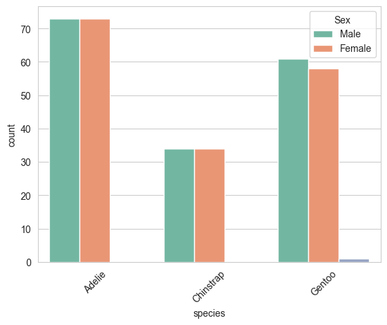

```python
# Create the countplot
sns.countplot(x='species', hue='sex', data=df, palette='Set2')

plt.legend(title='Sex', loc='upper right', labels=['Male', 'Female'])

plt.xticks(rotation=45)
plt.show()
```

Gender balance across species.

```
([0, 1, 2],
 [Text(0, 0, 'Torgersen'), Text(1, 0, 'Biscoe'), Text(2, 0, 'Dream')])
```

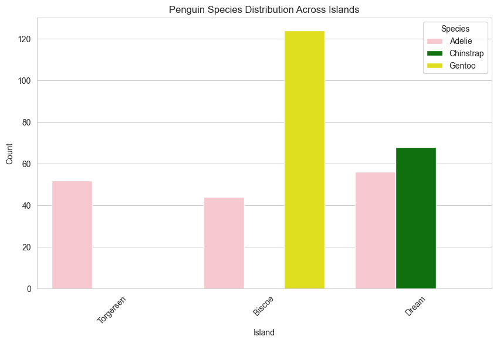

```python
plt.figure(figsize=(10, 6))
sns.countplot(x='island', hue='species', data=df, palette=custom_palette)
plt.legend(title='Species', loc='upper right')

plt.title('Penguin Species Distribution Across Islands')
plt.xlabel('Island')
plt.ylabel('Count')
plt.xticks(rotation=45)
```

The Gentoo species exclusively inhabits Biscoe Island, the Chinstrap species is found solely on Dream Island, while the Adelie species is distributed across multiple islands.

## Categorical variables

```python
# Define the categorical variables
categorical_vars = ['species', 'island', 'sex']
```

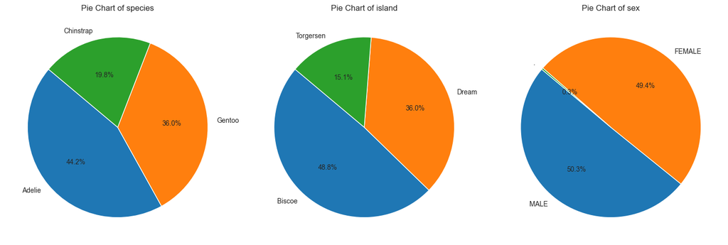

```python
plt.figure(figsize=(15, 5))
plt.subplots_adjust(wspace=0.5)

for i, var in enumerate(categorical_vars, 1):
    plt.subplot(1, 3, i)
    var_counts = df[var].value_counts()
    plt.pie(var_counts, labels=var_counts.index, autopct='%1.1f%%', startangle=140)
    plt.title(f'Pie Chart of {var}')

plt.tight_layout()
plt.show()
```

## Numerical variables

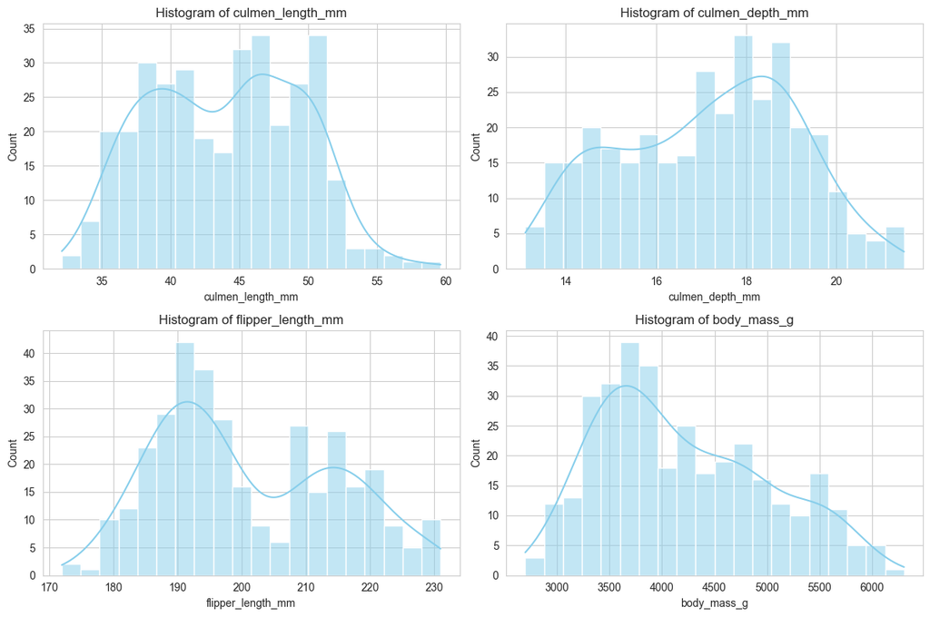

```python
# Select numerical columns
numerical_cols = ['culmen_length_mm', 'culmen_depth_mm', 'flipper_length_mm', 'body_mass_g']

plt.figure(figsize=(12, 8))
plt.subplots_adjust(hspace=0.5, wspace=0.5)

for i, col in enumerate(numerical_cols, 1):
    plt.subplot(2, 2, i)
    sns.histplot(df[col].dropna(), kde=True, bins=20, color='skyblue')
    plt.title(f'Histogram of {col}')
    plt.xlabel(col)
    plt.ylabel('Count')

plt.tight_layout()
plt.show()
```

```python
def determine_distribution_shape(data, numerical_cols):
    """
    Determine the shape of distribution for numerical variables.

    Parameters:
    - data: DataFrame containing the dataset
    - numerical_cols: List of numerical columns to analyze

    Prints:
    - Distribution shape for each numerical variable
    """
    for col in numerical_cols:
        skewness = data[col].skew()

        if skewness > 0:
            skew_type = 'right-skewed'
        elif skewness < 0:
            skew_type = 'left-skewed'
        else:
            skew_type = 'approximately normal'

        print(f"{col}: {skew_type} (Skewness = {skewness:.2f})")

determine_distribution_shape(df, numerical_cols)
```

```
culmen_length_mm: right-skewed (Skewness = 0.05)
culmen_depth_mm: left-skewed (Skewness = -0.14)
flipper_length_mm: right-skewed (Skewness = 0.35)
body_mass_g: right-skewed (Skewness = 0.47)
```

Exception: culmen_length_mm: Skewness = 0.05 (close to 0) indicates a nearly symmetrical distribution, which can be considered approximately normal.

##### Imputing missing values

```
culmen_length_mm      2 : With mean
culmen_depth_mm       2 : With median
flipper_length_mm     2 : With median
body_mass_g           2 : With median
sex                  10 : with mode
```

```python
df['culmen_length_mm'].fillna(df['culmen_length_mm'].mean(), inplace=True)
df['culmen_depth_mm'].fillna(df['culmen_depth_mm'].median(), inplace=True)
df['flipper_length_mm'].fillna(df['flipper_length_mm'].median(), inplace=True)
df['body_mass_g'].fillna(df['body_mass_g'].median(), inplace=True)
df['sex'].fillna(df['sex'].mode()[0], inplace=True)
```

[output not shown]

```python
# Replace '.' in sex with the mode value
df['sex'] = df['sex'].replace('.', df['sex'].mode()[0])
```

```python
#count total rows in each column which contain null values
df.isna().sum()
```

```
species              0
island               0
culmen_length_mm     0
culmen_depth_mm      0
flipper_length_mm    0
body_mass_g          0
sex                  0
dtype: int64
```

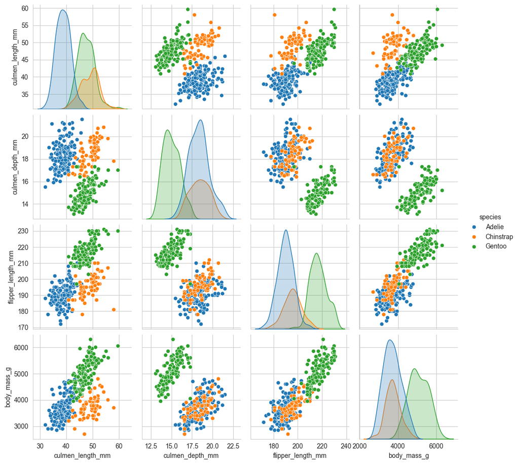

```python
## Pair plots

sns.pairplot(df, hue='species')  # Pairplot to visualize relationships
plt.show()
```

There exist linear relationships between certain pairs of variables, particularly between flipper_length_mm and body_mass_g.

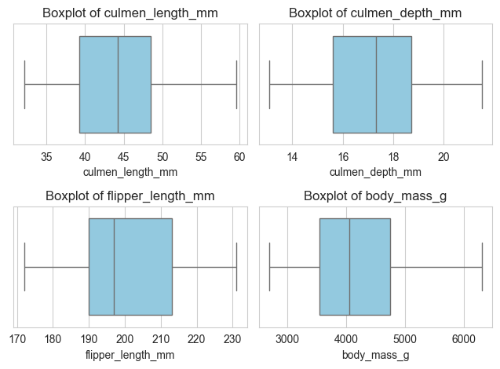

```python
# Box plots

for i, col in enumerate(numerical_cols, 1):
    plt.subplot(2, 2, i)
    sns.boxplot(x=df[col], color='skyblue')
    plt.title(f'Boxplot of {col}')
    plt.xlabel(col)

# Show the plot
plt.tight_layout()
plt.show()
```

```python
#find the outliers in each of the column
def outliers_iqr(ys):
    quartile_1, quartile_3 = np.percentile(ys, [25, 75])
    iqr = quartile_3 - quartile_1
    lower_bound = quartile_1 - (iqr * 1.5)
    upper_bound = quartile_3 + (iqr * 1.5)
    return np.where((ys > upper_bound) | (ys < lower_bound))

print("Outliers: \n")
for item in numerical_cols:
    print(item,': ',outliers_iqr(df[item]))
```

```
Outliers:

culmen_length_mm :  (array([], dtype=int64),)
culmen_depth_mm :  (array([], dtype=int64),)
flipper_length_mm :  (array([], dtype=int64),)
body_mass_g :  (array([], dtype=int64),)
```

There are no outliers.

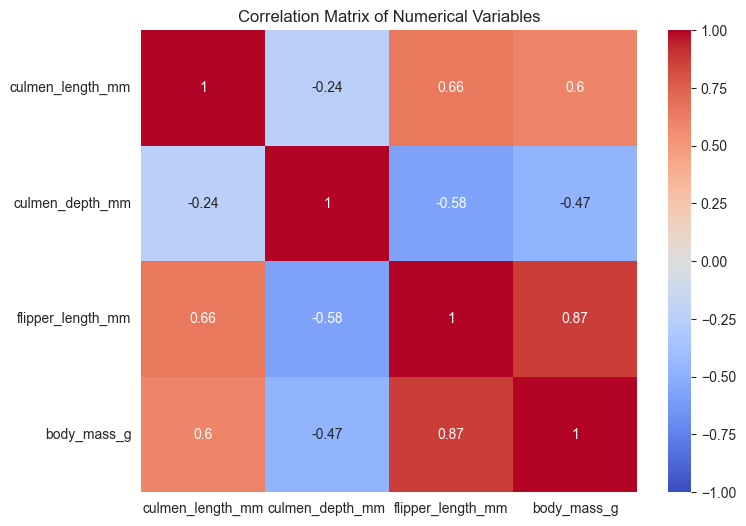

```python
# Compute the correlation matrix
corr_matrix = df[numerical_cols].corr()

plt.figure(figsize=(8, 6))

sns.heatmap(corr_matrix, annot=True, cmap='coolwarm', vmin=-1, vmax=1)

plt.title('Correlation Matrix of Numerical Variables')
plt.show()
```

flipper_length_mm - body_mass_g : High Correlation = 0.87

```python
# Check and convert data types to numeric if necessary
df1 = df[numerical_cols].apply(pd.to_numeric, errors='coerce')

# Calculate VIF for each variable
vif_data = pd.DataFrame()
vif_data["Variable"] = df1.columns
vif_data["VIF"] = [variance_inflation_factor(df1.values, i) for i in range(len(df1.columns))]

# Print the VIF values
print(vif_data)
```

```
            Variable         VIF
0   culmen_length_mm  118.667924
1    culmen_depth_mm   54.671037
2  flipper_length_mm  276.233809
3        body_mass_g   86.663731
```

#### Convert categorical values with numeric codes

```python
# Mapping dictionaries
species_map = {'Adelie': 0, 'Gentoo': 1, 'Chinstrap': 2}
island_map = {'Biscoe': 0, 'Dream': 1, 'Torgersen': 2}
sex_map = {'MALE': 0, 'FEMALE': 1}

# Replace categorical values with numeric codes
df['species'] = df['species'].replace(species_map)
df['island'] = df['island'].replace(island_map)
df['sex'] = df['sex'].replace(sex_map)
```

```python
df.head()
```

|  | species | island | culmen_length_mm | culmen_depth_mm | flipper_length_mm | body_mass_g | sex |
| --- | --- | --- | --- | --- | --- | --- | --- |
| 0 | 0 | 2 | 39.10000 | 18.7 | 181.0 | 3750.0 | 0 |
| 1 | 0 | 2 | 39.50000 | 17.4 | 186.0 | 3800.0 | 1 |
| 2 | 0 | 2 | 40.30000 | 18.0 | 195.0 | 3250.0 | 1 |
| 3 | 0 | 2 | 43.92193 | 17.3 | 197.0 | 4050.0 | 0 |
| 4 | 0 | 2 | 36.70000 | 19.3 | 193.0 | 3450.0 | 1 |

# Machine Learning

Perform a train/test split of 80/20 and model your data on a Linear Discriminant classifier to categorize penguin species. Include all numerical features in the model.

```python
from sklearn.model_selection import train_test_split
from sklearn.preprocessing import StandardScaler
from sklearn.discriminant_analysis import LinearDiscriminantAnalysis
from sklearn.metrics import confusion_matrix, classification_report, roc_curve, auc, roc_auc_score, accuracy_score
```

```python
# Encode columns into numeric
from sklearn.preprocessing import LabelEncoder
for column in df.columns:
    le = LabelEncoder()
    df[column] = le.fit_transform(df[column])
```

```python
df
```

|  | species | island | culmen_length_mm | culmen_depth_mm | flipper_length_mm | body_mass_g | sex |
| --- | --- | --- | --- | --- | --- | --- | --- |
| 0 | 0 | 2 | 42 | 56 | 6 | 31 | 0 |
| 1 | 0 | 2 | 45 | 43 | 11 | 33 | 1 |
| 2 | 0 | 2 | 51 | 49 | 20 | 12 | 1 |
| 3 | 0 | 2 | 82 | 42 | 22 | 41 | 0 |
| 4 | 0 | 2 | 22 | 62 | 18 | 19 | 1 |
| ... | ... | ... | ... | ... | ... | ... | ... |
| 339 | 1 | 0 | 82 | 42 | 22 | 41 | 0 |
| 340 | 1 | 0 | 106 | 12 | 39 | 66 | 1 |
| 341 | 1 | 0 | 137 | 26 | 46 | 87 | 0 |
| 342 | 1 | 0 | 90 | 17 | 36 | 76 | 1 |
| 343 | 1 | 0 | 132 | 30 | 37 | 80 | 0 |

344 rows × 7 columns

```python
X = df.drop(columns=['species'])
y = df['species']
```

```python
# Initialize StandardScaler
scaler = StandardScaler()

# Fit and transform the numerical columns in X
X[numerical_cols] = scaler.fit_transform(X[numerical_cols])
```

```python
X
```

|  | island | culmen_length_mm | culmen_depth_mm | flipper_length_mm | body_mass_g | sex |
| --- | --- | --- | --- | --- | --- | --- |
| 0 | 2 | -0.892720 | 0.797086 | -1.447710 | -0.523420 | 0 |
| 1 | 2 | -0.824683 | 0.130936 | -1.076170 | -0.441984 | 1 |
| 2 | 2 | -0.688609 | 0.438390 | -0.407398 | -1.297069 | 1 |
| 3 | 2 | 0.014438 | 0.079694 | -0.258782 | -0.116237 | 0 |
| 4 | 2 | -1.346298 | 1.104540 | -0.556014 | -1.012041 | 1 |
| ... | ... | ... | ... | ... | ... | ... |
| 339 | 0 | 0.014438 | 0.079694 | -0.258782 | -0.116237 | 0 |
| 340 | 0 | 0.558733 | -1.457576 | 1.004454 | 0.901722 | 1 |
| 341 | 0 | 1.261780 | -0.740183 | 1.524610 | 1.756808 | 0 |
| 342 | 0 | 0.195870 | -1.201364 | 0.781530 | 1.308906 | 1 |
| 343 | 0 | 1.148385 | -0.535214 | 0.855838 | 1.471780 | 0 |

344 rows × 6 columns

```python
# Perform train/test split (80/20)
X_train, X_test, y_train, y_test = train_test_split(X, y, test_size=0.2, random_state=42)
```

```python
# Initialize and train the LDA model
lda = LinearDiscriminantAnalysis()
lda.fit(X_train, y_train)
```

```
LinearDiscriminantAnalysis()
```

```python
# Extract linear discriminant functions (coefficients)
coef = lda.coef_
intercept = lda.intercept_
```

```python
intercept
```

```
array([ -7.45708679, -13.36423661, -10.63730881])
```

```python
# Print the coefficients and intercepts
print("Linear Discriminant Functions:")
for i, feature in enumerate(X.columns):
    print(f"{feature}: Coefficients: {coef[0][i]}")
```

```
Linear Discriminant Functions:
island: Coefficients: 1.8987806028244063
culmen_length_mm: Coefficients: -4.681419979131724
culmen_depth_mm: Coefficients: 5.767358261604949
flipper_length_mm: Coefficients: -4.079331046271138
body_mass_g: Coefficients: -2.434628128399557
sex: Coefficients: -2.5584786761533467
```

species_map = {'Adelie': 0, 'Gentoo': 1, 'Chinstrap': 2}

[output not shown]

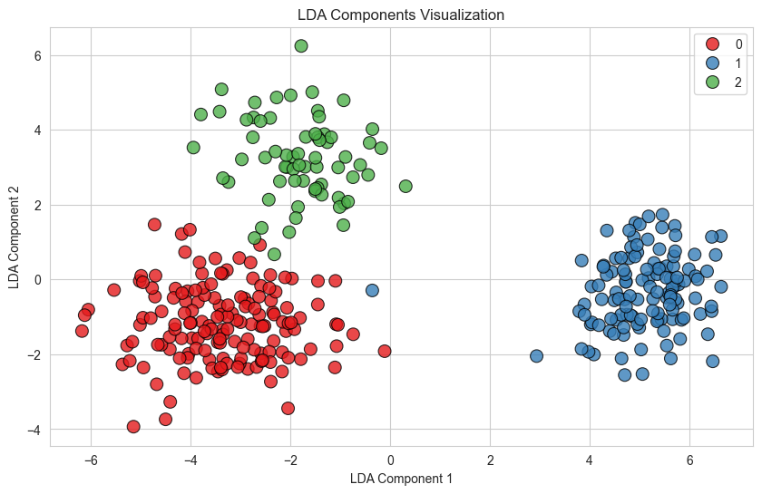

```python
# Visualizing 'LDA Component 1' and 'LDA Component 2'
lda = LinearDiscriminantAnalysis(n_components=2)
X_lda = lda.fit_transform(X, y)

# Create a DataFrame for visualization (optional, depending on your data structure)
df_lda = pd.DataFrame(data=X_lda, columns=['LDA Component 1', 'LDA Component 2'])
df_lda['Target'] = y

# Visualize LDA Components
plt.figure(figsize=(10, 6))
sns.scatterplot(x='LDA Component 1', y='LDA Component 2', hue='Target', data=df_lda, palette='Set1', s=100, edgecolor='k', alpha=0.8)
plt.title('LDA Components Visualization')
plt.xlabel('LDA Component 1')
plt.ylabel('LDA Component 2')
plt.legend()
plt.grid(True)
plt.show()
```

## Evaluate the LDA model performance with the precision, recall, f1 score, accuracy and confusion matrix.

```python
# Evaluate model on test dataset
y_pred = lda.predict(X_test)
```

```python
from sklearn import metrics
# Model Accuracy, how often is the classifier correct?
print("Accuracy:",metrics.accuracy_score(y_test, y_pred))
```

```
Accuracy: 0.9855072463768116
```

```python
# Compute confusion matrix
conf_matrix = confusion_matrix(y_test, y_pred)
print("Confusion Matrix:")
print(conf_matrix)
```

```
Confusion Matrix:
[[32  0  0]
 [ 0 21  0]
 [ 1  0 15]]
```

```python
# Print classification report for more detailed evaluation
class_names = np.unique(y)
print("\nClassification Report:")
print(classification_report(y_test, y_pred, target_names=[f'Specie {int(i)}' for i in class_names]))
```

```
Classification Report:
              precision    recall  f1-score   support

    Specie 0       0.97      1.00      0.98        32
    Specie 1       1.00      1.00      1.00        21
    Specie 2       1.00      0.94      0.97        16

    accuracy                           0.99        69
   macro avg       0.99      0.98      0.98        69
weighted avg       0.99      0.99      0.99        69
```

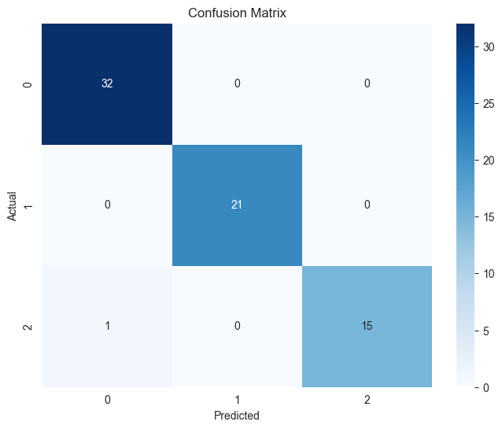

```python
# Plot confusion matrix
plt.figure(figsize=(8, 6))
sns.heatmap(conf_matrix, annot=True, cmap='Blues', fmt='d', xticklabels=class_names, yticklabels=class_names)
plt.title('Confusion Matrix')
plt.xlabel('Predicted')
plt.ylabel('Actual')
plt.show()
```

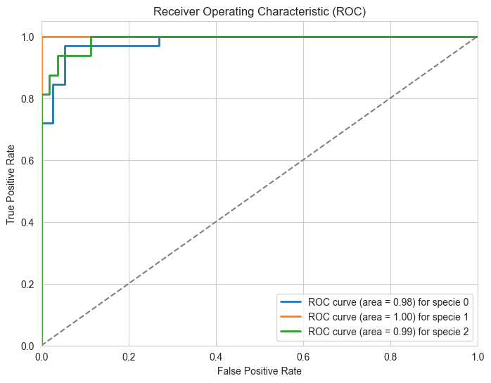

```python
# Compute ROC curve and ROC area for each specie
y_score = lda.decision_function(X_test)
y_test_bin = label_binarize(y_test, classes=class_names)

fpr = dict()
tpr = dict()
roc_auc = dict()

for i in range(len(class_names)):
    fpr[i], tpr[i], _ = roc_curve(y_test_bin[:, i], y_score[:, i])
    roc_auc[i] = roc_auc_score(y_test_bin[:, i], y_score[:, i])

# Plot ROC curves
plt.figure(figsize=(8, 6))
for i in range(len(class_names)):
    plt.plot(fpr[i], tpr[i], lw=2, label=f'ROC curve (area = {roc_auc[i]:.2f}) for specie {int(class_names[i])}')

plt.plot([0, 1], [0, 1], color='gray', linestyle='--')
plt.xlim([0.0, 1.0])
plt.ylim([0.0, 1.05])
plt.xlabel('False Positive Rate')
plt.ylabel('True Positive Rate')
plt.title('Receiver Operating Characteristic (ROC)')
plt.legend(loc='lower right')
plt.show()
```

## With the same set of train/test and predictors as above, build a random forest model to classify the penguin species.

```python
from sklearn.ensemble import RandomForestClassifier
```

```python
# Initialize and train the Random Forest classifier
rf = RandomForestClassifier(random_state=42)
rf.fit(X_train, y_train)
```

```
RandomForestClassifier(random_state=42)
```

```python
y_pred_rf = rf.predict(X_train)
```

```python
# Model Accuracy
accuracy = accuracy_score(y_train, y_pred_rf)
print(f"Model Accuracy: {accuracy:.2f}\n")
```

```
Model Accuracy: 1.00
```

```python
# Confusion Matrix
conf_matrix = confusion_matrix(y_train, y_pred_rf)
print("Confusion Matrix:")
print(conf_matrix)
print()
```

```
Confusion Matrix:
[[120   0   0]
 [  0 103   0]
 [  0   0  52]]
```

```python
# Classification Report
print("Classification Report:")
class_report = classification_report(y_train, y_pred_rf)
print(class_report)
```

```
Classification Report:
              precision    recall  f1-score   support

           0       1.00      1.00      1.00       120
           1       1.00      1.00      1.00       103
           2       1.00      1.00      1.00        52

    accuracy                           1.00       275
   macro avg       1.00      1.00      1.00       275
weighted avg       1.00      1.00      1.00       275
```

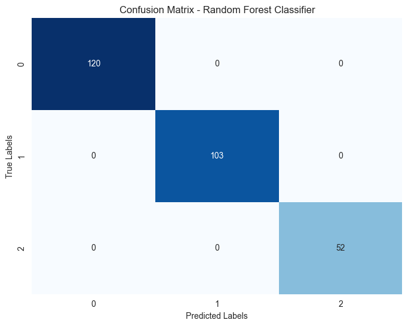

```python
# Compute confusion matrix
conf_matrix = confusion_matrix(y_train, y_pred_rf)

# Plot confusion matrix
plt.figure(figsize=(8, 6))
sns.heatmap(conf_matrix, annot=True, fmt='d', cmap='Blues', cbar=False,
            xticklabels=rf.classes_, yticklabels=rf.classes_)
plt.xlabel('Predicted Labels')
plt.ylabel('True Labels')
plt.title('Confusion Matrix - Random Forest Classifier')
plt.show()
```

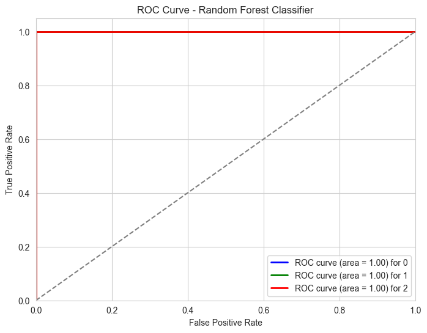

```python
# Predict probabilities for each class using Random Forest
y_score_rf = rf.predict_proba(X_train)

# Binarize the labels for multi-class ROC
y_train_bin = label_binarize(y_train, classes=rf.classes_)

# Compute ROC curve and ROC area for each class
fpr = dict()
tpr = dict()
roc_auc = dict()

for i, species_name in enumerate(rf.classes_):
    fpr[i], tpr[i], _ = roc_curve(y_train_bin[:, i], y_score_rf[:, i])
    roc_auc[i] = auc(fpr[i], tpr[i])

# Plot ROC curves
plt.figure(figsize=(8, 6))
colors = ['b', 'g', 'r']  # Adjust colors if more classes
for i, species_name in enumerate(rf.classes_):
    plt.plot(fpr[i], tpr[i], color=colors[i], lw=2,
             label=f'ROC curve (area = {roc_auc[i]:.2f}) for {species_name}')

plt.plot([0, 1], [0, 1], color='gray', linestyle='--')
plt.xlim([0.0, 1.0])
plt.ylim([0.0, 1.05])
plt.xlabel('False Positive Rate')
plt.ylabel('True Positive Rate')
plt.title('ROC Curve - Random Forest Classifier')
plt.legend(loc="lower right")
plt.grid(True)
plt.show()
```

### Comparison

```python
# Define the metrics from LDA and Random Forest classification reports
lda_metrics = {
    'Model': ['LDA'] * 3,
    'Class': ['Specie 0', 'Specie 1', 'Specie 2'],
    'Precision': [0.97, 1.00, 1.00],
    'Recall': [1.00, 1.00, 0.94],
    'F1-Score': [0.98, 1.00, 0.97],
    'Support': [32, 21, 16],
    'Accuracy': [0.985] * 3
}

rf_metrics = {
    'Model': ['Random Forest'] * 3,
    'Class': [0, 1, 2],
    'Precision': [1.00, 1.00, 1.00],
    'Recall': [1.00, 1.00, 1.00],
    'F1-Score': [1.00, 1.00, 1.00],
    'Support': [120, 103, 52],
    'Accuracy': [1.00] * 3
}

# Create DataFrames
df_lda = pd.DataFrame(lda_metrics)
df_rf = pd.DataFrame(rf_metrics)

# Concatenate DataFrames
df_comparison = pd.concat([df_lda, df_rf], ignore_index=True)

# Display the comparison DataFrame
print("Performance Comparison:")
print(df_comparison)
```

```
Performance Comparison:
           Model     Class  Precision  Recall  F1-Score  Support  Accuracy
0            LDA  Specie 0       0.97    1.00      0.98       32     0.985
1            LDA  Specie 1       1.00    1.00      1.00       21     0.985
2            LDA  Specie 2       1.00    0.94      0.97       16     0.985
3  Random Forest         0       1.00    1.00      1.00      120     1.000
4  Random Forest         1       1.00    1.00      1.00      103     1.000
5  Random Forest         2       1.00    1.00      1.00       52     1.000
```

Comments:

```
LDA (Linear Discriminant Analysis):
    Achieves high precision, recall, and F1-score across all three classes (Specie 0, Specie 1, Specie 2).
    Overall accuracy is 0.99.

Random Forest:
    Also achieves perfect precision, recall, and F1-score across all three classes.
    Overall accuracy is 1.00.
```

Comparison:

[output not shown]

# Insights

In the context of the penguin dataset, which is a small dataset, a Random Forest model might be preferable over an LDA (Linear Discriminant Analysis) model for several reasons

- Random Forests offer flexibility, robustness, and the ability to capture complex relationships that may make them preferable for classification tasks in datasets like the Palmer Archipelago penguin dataset.
- Given the imbalance in the dataset where Chinstrap penguins account for only 19.8% and Adelie penguins the majority at 44.2%, handling this imbalance appropriately is crucial for model performance and interpretation. Unlike LDA, which assumes that the predictors are normally distributed within each class, Random Forests have no such distributional assumptions.
- Random Forests are ensemble models that combine multiple decision trees, which perform better in scenarios where the data is unbalanced.

However, when dealing with large datasets, LDA tends to process quickly and efficiently, enabling rapid learning and effective sampling for optimal results. However, LDA's sensitivity to outliers can impact its performance.

On the other hand, Random Forests consume more computational resources due to their ensemble nature, which involves building multiple decision trees. Despite this, Random Forests excel in scenarios where datasets are small. In such cases, while the differences in performance might be subtle, Random Forests typically deliver superior results.